# Forecaster’s toolbox

# Lab session 5: specify and train models

# Fittig model, specify and estimate parameters in fable

We start with simple benchmark method: average, naive, snaive

We specify models using the function corresponding to the name of the forecasting model. We use a formula (response ~ terms) to specify methods and estimate parameters using `model()` function. If there is no term for the method (e.g. `MEAN(arrival)`), we ignore the `~` and terms:

Now, run the following R chunk:

```r
admission_fit <- admission_daily %>%
  model(
    mean = MEAN(arrival),#total average
    naive = NAIVE(arrival),#naive
    snaive = SNAIVE(arrival),#seasonal naive
    exponential_smoothing = ETS(arrival), #exponential smoothing models
    arima = ARIMA(arrival), #arima models
    regression = TSLM(arrival), #time series linear progression models
  )
```

You can observe `admission_fit` object by selecting it and run.

`admission_fit` is called `mable`, it is model table, each row belongs to one time series and each column to a model

Now we can extract information or look into details of the trained models(mable) using `tidy()`, `report()`, `glance()` and `augment()`

These function would reveal more information when used with models with parameters such as exponential smoothing (ETS), but here you can try them with simple methods and use them with ETS in the next tutorial as well:

```r
admission_fit %>% tidy()
```

```
## # A tibble: 18 × 6
##    .model                term        estimate std.error statistic   p.value
##    <chr>                 <chr>          <dbl>     <dbl>     <dbl>     <dbl>
##  1 mean                  mean        321.        0.619    518.     0
##  2 exponential_smoothing alpha         0.197    NA         NA     NA
##  3 exponential_smoothing gamma         0.0176   NA         NA     NA
##  4 exponential_smoothing l[0]        296.       NA         NA     NA
##  5 exponential_smoothing s[0]         -7.70     NA         NA     NA
##  6 exponential_smoothing s[-1]       -10.5      NA         NA     NA
##  7 exponential_smoothing s[-2]         0.507    NA         NA     NA
##  8 exponential_smoothing s[-3]        27.8      NA         NA     NA
##  9 exponential_smoothing s[-4]        16.1      NA         NA     NA
## 10 exponential_smoothing s[-5]       -10.3      NA         NA     NA
## 11 exponential_smoothing s[-6]       -15.9      NA         NA     NA
## 12 arima                 ar1          -0.0995    0.208     -0.478  6.32e- 1
## 13 arima                 ar2           0.0545    0.0648     0.841  4.01e- 1
## 14 arima                 ma1          -0.569     0.207     -2.76   5.89e- 3
## 15 arima                 ma2          -0.358     0.198     -1.81   7.08e- 2
## 16 arima                 sma1          0.244     0.0220    11.1    6.28e-28
## 17 arima                 sma2          0.177     0.0194     9.12   1.63e-19
## 18 regression            (Intercept) 321.        0.619    518.     0
```

```r
admission_fit %>% glance()
```

```
## # A tibble: 6 × 20
##   .model   sigma2 log_lik    AIC   AICc    BIC   MSE  AMSE   MAE ar_ro…¹ ma_ro…²
##   <chr>     <dbl>   <dbl>  <dbl>  <dbl>  <dbl> <dbl> <dbl> <dbl> <list>  <list>
## 1 mean       875.     NA     NA     NA     NA    NA    NA   NA   <NULL>  <NULL>
## 2 naive     1000.     NA     NA     NA     NA    NA    NA   NA   <NULL>  <NULL>
## 3 snaive     932.     NA     NA     NA     NA    NA    NA   NA   <NULL>  <NULL>
## 4 exponen…   513. -15939. 31897. 31897. 31954.  511.  539.  17.7 <NULL>  <NULL>
## 5 arima      610. -10550. 21114. 21114. 21154.   NA    NA   NA   <cpl>   <cpl>
## 6 regress…   875. -10966. 15461. 15461. 15472.   NA    NA   NA   <NULL>  <NULL>
## # … with 9 more variables: r_squared <dbl>, adj_r_squared <dbl>,
## #   statistic <lgl>, p_value <lgl>, df <int>, CV <dbl>, deviance <dbl>,
## #   df.residual <int>, rank <int>, and abbreviated variable names ¹ar_roots,
## #   ²ma_roots
```

```r
admission_fit %>% augment()
```

```
## # A tsibble: 13,692 x 6 [1D]
## # Key:       .model [6]
##    .model time       arrival .fitted .resid .innov
##    <chr>  <date>       <int>   <dbl>  <dbl>  <dbl>
##  1 mean   2010-01-01     355    321.  34.3   34.3
##  2 mean   2010-01-02     318    321.  -2.73  -2.73
##  3 mean   2010-01-03     283    321. -37.7  -37.7
##  4 mean   2010-01-04     263    321. -57.7  -57.7
##  5 mean   2010-01-05     274    321. -46.7  -46.7
##  6 mean   2010-01-06     258    321. -62.7  -62.7
##  7 mean   2010-01-07     317    321.  -3.73  -3.73
##  8 mean   2010-01-08     293    321. -27.7  -27.7
##  9 mean   2010-01-09     296    321. -24.7  -24.7
## 10 mean   2010-01-10     287    321. -33.7  -33.7
## # … with 13,682 more rows
```

```r
admission_fit %>% select(snaive) %>% report()
```

```
## Series: arrival
## Model: SNAIVE
##
## sigma^2: 932.012
```

You can extract fitted values and residuals for each model using `augment()` . You can then use filter() to extract information for any model and select `.fitted` or `.resid`

```r
admission_fit %>% augment()
```

```
## # A tsibble: 13,692 x 6 [1D]
## # Key:       .model [6]
##    .model time       arrival .fitted .resid .innov
##    <chr>  <date>       <int>   <dbl>  <dbl>  <dbl>
##  1 mean   2010-01-01     355    321.  34.3   34.3
##  2 mean   2010-01-02     318    321.  -2.73  -2.73
##  3 mean   2010-01-03     283    321. -37.7  -37.7
##  4 mean   2010-01-04     263    321. -57.7  -57.7
##  5 mean   2010-01-05     274    321. -46.7  -46.7
##  6 mean   2010-01-06     258    321. -62.7  -62.7
##  7 mean   2010-01-07     317    321.  -3.73  -3.73
##  8 mean   2010-01-08     293    321. -27.7  -27.7
##  9 mean   2010-01-09     296    321. -24.7  -24.7
## 10 mean   2010-01-10     287    321. -33.7  -33.7
## # … with 13,682 more rows
```

```r
admission_fit %>% augment() %>% filter(.model=="snaive") %>% select(.fitted)#select fitted values
```

```
## # A tsibble: 2,282 x 2 [1D]
##    .fitted time
##      <dbl> <date>
##  1      NA 2010-01-01
##  2      NA 2010-01-02
##  3      NA 2010-01-03
##  4      NA 2010-01-04
##  5      NA 2010-01-05
##  6      NA 2010-01-06
##  7      NA 2010-01-07
##  8     355 2010-01-08
##  9     318 2010-01-09
## 10     283 2010-01-10
## # … with 2,272 more rows
```

```r
admission_fit %>% augment() %>% filter(.model=="snaive") %>% select(.resid)# select residuals
```

```
## # A tsibble: 2,282 x 2 [1D]
##    .resid time
##     <dbl> <date>
##  1     NA 2010-01-01
##  2     NA 2010-01-02
##  3     NA 2010-01-03
##  4     NA 2010-01-04
##  5     NA 2010-01-05
##  6     NA 2010-01-06
##  7     NA 2010-01-07
##  8    -62 2010-01-08
##  9    -22 2010-01-09
## 10      4 2010-01-10
## # … with 2,272 more rows
```

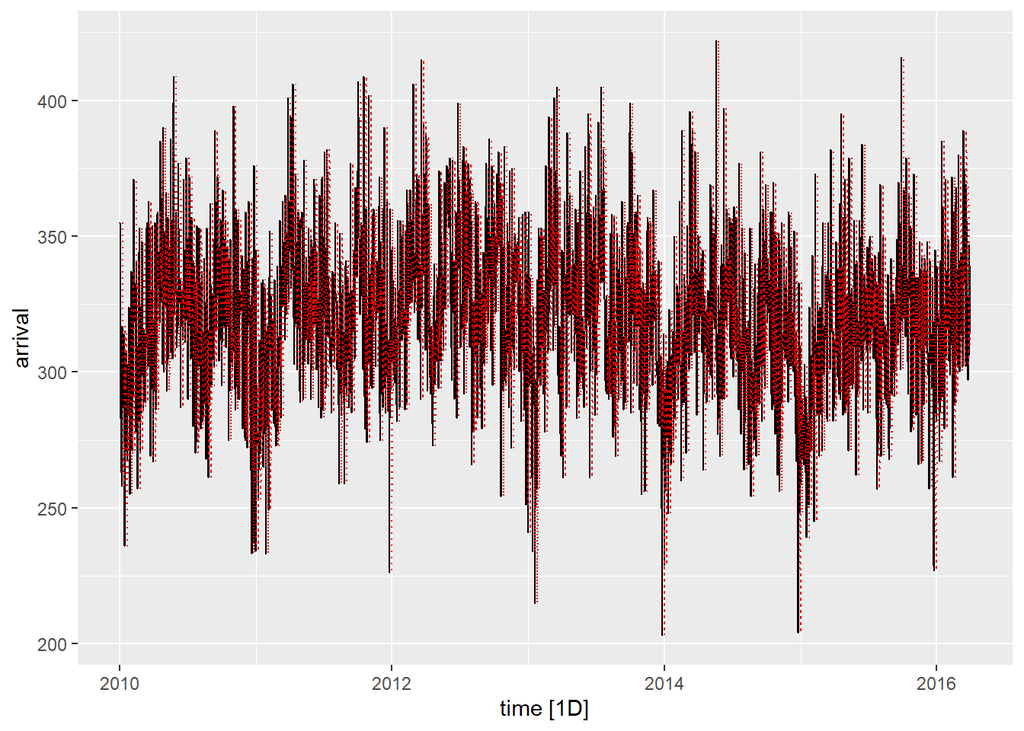

```r
fit <- admission_fit %>% augment() %>%
  filter(.model=="snaive")

fit %>% autoplot(arrival) +
autolayer(fit, .fitted, color="red", lty=3)
```

In order to produce forecasts, we pass `admission_fit`, the mable object, to the `forecast()` function:

```r
admission_fc <- admission_fit %>% forecast(h=42)
```

Forecast function needs the forecast horizon as argument, h=“42 days” or h=42

We can also plot generated forecasts using models, if you don’t want to plot prediction intervals, then use `level=NULL`

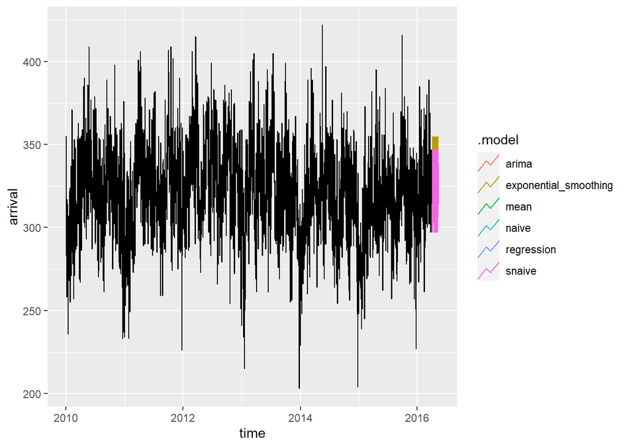

```r
admission_fc %>%
  autoplot(admission_daily,level=NULL)
```

It is hard to see the forecast lines, so we plot only a part of the time series data. `filter_index()` is used for this:

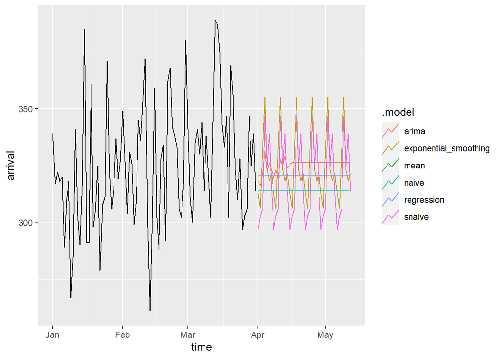

```r
admission_fc %>% autoplot(filter_index(admission_daily,"2016"~.), level=NULL)
```

# Lab session 6: Evaluate and report forecast accuracy

In a typical forecasting task, you compare multiple forecasting models and choose one that provides more accuracy. The most robust way to choose the best forecasting model is to use time series cross validation.

## Time series cross validation

This is also called rolling forecast or rolling origin: You can also reflect on the following questions: - Why do we use TSCV? you can read more here: https://otexts.com/fpp3/tscv.html - How do we do TSCV in R? Which steps to follow? 1. split data using `filter_index()` 2. create different time series (different origins) 2. model each time series, 3. forecast for each series

let’s see how we do it in R:

1. split data

```r
f_horizon <- 42# forecast horizon

percentage_test <- 0.2

test <- admission_daily %>%

  filter_index(as.character(max(admission_daily$time)-round(percentage_test*nrow(admission_daily))+1) ~ .)



train <- admission_daily %>%

  filter_index(. ~ as.character(max(admission_daily$time)-(round(percentage_test*nrow(admission_daily)))))
```

2. Use `stretch_tsibble()` to Create different timeseries (i.e different id)

We apply time series cross validation on the train data. We first start with an initial training size (.init = ) and then increase the size of the previous time series by adding more new observation(.step=) to create a new time series, we continue creating these timeseries until the number of observation left at the end of timeseries equals to the forecast horizon, we stop there.

```r
train_tscv <- admission_daily %>% # split data into series with increasing size
  filter_index(. ~ as.character(max(admission_daily$time) - f_horizon)) %>%
  stretch_tsibble(.init = length(train$time), .step = 7)
```

`.init` is the size of initial time series, `.step` is the increment step >=1, this can correspond to the forecasting frequency, how often you generate the forecast. if .step=1 in a daily time series, it means we generate forecasts every day for the next 42 days (forecast horizon=42)

How many time series(samples) we create with this process? what is the new variable .id?

3. train models for each time series (for each value of `.id` variable)

```r
ae_model_tscv <- train_tscv %>%
  model(
    mean = MEAN(arrival),#total average
    naive = NAIVE(arrival),#naive
    snaive = SNAIVE(arrival),#seasonal naive
    exponential_smoothing = ETS(arrival), #exponential smoothing models
    arima = ARIMA(arrival), #arima models
    regression = TSLM(arrival)
  )
```

You can observe `ae_model_tscv` by selecting (just double click on it) and running it, this is our model table (mable). We get one column for each forecasting model that is applied to each time series (rows). inside each cell(e.g.<S3: lst_mdl>) we have the fitted (trained) model with its components and parameters.

You can also use the functions introduced above to investigate fitted models to each .id:

```r
ae_model_tscv %>% tidy()
```

```
## # A tibble: 1,080 × 7
##      .id .model                term    estimate std.error statistic p.value
##    <int> <chr>                 <chr>      <dbl>     <dbl>     <dbl>   <dbl>
##  1     1 mean                  mean  322.           0.698      461.       0
##  2     1 exponential_smoothing alpha   0.204       NA           NA       NA
##  3     1 exponential_smoothing gamma   0.000100    NA           NA       NA
##  4     1 exponential_smoothing l[0]  296.          NA           NA       NA
##  5     1 exponential_smoothing s[0]   -7.08        NA           NA       NA
##  6     1 exponential_smoothing s[-1]  -7.79        NA           NA       NA
##  7     1 exponential_smoothing s[-2]  -1.61        NA           NA       NA
##  8     1 exponential_smoothing s[-3]  24.1         NA           NA       NA
##  9     1 exponential_smoothing s[-4]  16.8         NA           NA       NA
## 10     1 exponential_smoothing s[-5]  -9.09        NA           NA       NA
## # … with 1,070 more rows
```

```r
ae_model_tscv %>% filter(.id==60) %>% glance() # if you want to observe one specific .id
```

```
## # A tibble: 6 × 21
##     .id .model     sigma2 log_lik    AIC   AICc    BIC   MSE  AMSE   MAE ar_ro…¹
##   <int> <chr>       <dbl>   <dbl>  <dbl>  <dbl>  <dbl> <dbl> <dbl> <dbl> <list>
## 1    60 mean         877.     NA     NA     NA     NA    NA    NA   NA   <NULL>
## 2    60 naive       1002.     NA     NA     NA     NA    NA    NA   NA   <NULL>
## 3    60 snaive       928.     NA     NA     NA     NA    NA    NA   NA   <NULL>
## 4    60 exponenti…   514. -15620. 31260. 31261. 31318.  512.  541.  17.7 <NULL>
## 5    60 arima        611. -10352. 20719. 20719. 20759.   NA    NA   NA   <cpl>
## 6    60 regression   877. -10762. 15175. 15175. 15186.   NA    NA   NA   <NULL>
## # … with 10 more variables: ma_roots <list>, r_squared <dbl>,
## #   adj_r_squared <dbl>, statistic <lgl>, p_value <lgl>, df <int>, CV <dbl>,
## #   deviance <dbl>, df.residual <int>, rank <int>, and abbreviated variable
## #   name ¹ar_roots
```

```r
ae_model_tscv %>% augment()
```

```
## # A tsibble: 731,700 x 7 [1D]
## # Key:       .id, .model [360]
##      .id .model time       arrival .fitted .resid .innov
##    <int> <chr>  <date>       <int>   <dbl>  <dbl>  <dbl>
##  1     1 mean   2010-01-01     355    322.  32.9   32.9
##  2     1 mean   2010-01-02     318    322.  -4.07  -4.07
##  3     1 mean   2010-01-03     283    322. -39.1  -39.1
##  4     1 mean   2010-01-04     263    322. -59.1  -59.1
##  5     1 mean   2010-01-05     274    322. -48.1  -48.1
##  6     1 mean   2010-01-06     258    322. -64.1  -64.1
##  7     1 mean   2010-01-07     317    322.  -5.07  -5.07
##  8     1 mean   2010-01-08     293    322. -29.1  -29.1
##  9     1 mean   2010-01-09     296    322. -26.1  -26.1
## 10     1 mean   2010-01-10     287    322. -35.1  -35.1
## # … with 731,690 more rows
```

4. forecast for each series

```r
ae_fcst_tscv <- ae_model_tscv %>% forecast(h=42)
ae_fcst_tscv #observe ae_fcst_tscv
```

```
## # A fable: 15,120 x 5 [1D]
## # Key:     .id, .model [360]
##      .id .model time           arrival .mean
##    <int> <chr>  <date>          <dist> <dbl>
##  1     1 mean   2015-01-01 N(322, 890)  322.
##  2     1 mean   2015-01-02 N(322, 890)  322.
##  3     1 mean   2015-01-03 N(322, 890)  322.
##  4     1 mean   2015-01-04 N(322, 890)  322.
##  5     1 mean   2015-01-05 N(322, 890)  322.
##  6     1 mean   2015-01-06 N(322, 890)  322.
##  7     1 mean   2015-01-07 N(322, 890)  322.
##  8     1 mean   2015-01-08 N(322, 890)  322.
##  9     1 mean   2015-01-09 N(322, 890)  322.
## 10     1 mean   2015-01-10 N(322, 890)  322.
## # … with 15,110 more rows
```

This will create a forecast table or `fable` object. Observe it and look at the columns. What is `arrival` and `.mean` in ae_fcst_tscv?

in `ae_fcst_tscv` (a fable object) each .id is representing the forecast for each series.

# Evaluate forecast accuracy

You calculate the point forecast accuracy using `accuracy()` function. `accuracy()` needs both the forecast object(fable) and actual data.

```r
fc_accuracy <- ae_fcst_tscv %>% accuracy(admission_daily)

fc_accuracy %>% select(.model, RMSE, MAE)
```

```
## # A tibble: 6 × 3
##   .model                 RMSE   MAE
##   <chr>                 <dbl> <dbl>
## 1 arima                  28.0  21.8
## 2 exponential_smoothing  25.5  20.0
## 3 mean                   27.8  21.9
## 4 naive                  34.6  27.1
## 5 regression             27.8  21.9
## 6 snaive                 31.2  24.4
```

This will provide a summary of multiple accuracy measures. The result is summarised automatically across all series (.id) using a simple average.

Now let’s see how we can get the accuracy measure for each .id separately instead of averaging across all of them. To do this, you need to use an additional argument in accuracy(by=):

```r
fc_accuracy_by_id <- ae_fcst_tscv %>% accuracy(admission_daily, by = c(".id",".model"))
```

We can now create some insightful visualizations:

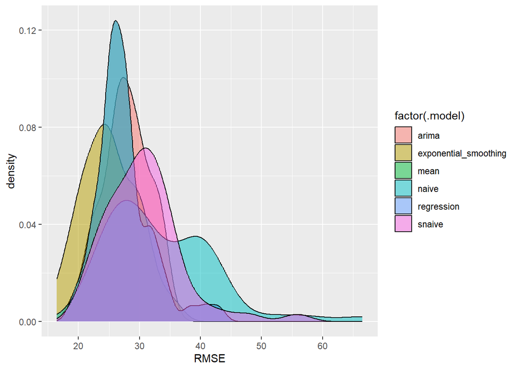

```r
fc_accuracy_density <- fc_accuracy_by_id %>% select(.id,.model,RMSE)
  ggplot(data=fc_accuracy_density, aes(RMSE))+
    geom_density(aes(fill=factor(.model)), alpha=.5)
```

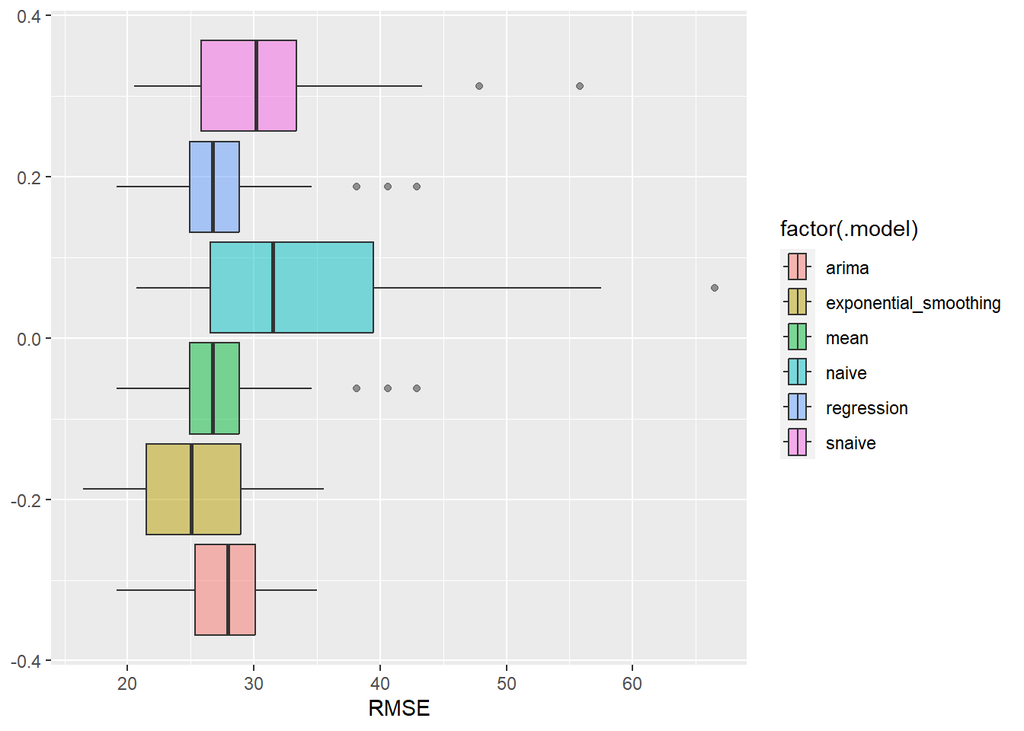

```r
fc_accuracy_boxplot <- fc_accuracy_by_id %>% select(.id,.model,RMSE)
ggplot(data=fc_accuracy_boxplot, aes(RMSE))+
    geom_boxplot(aes(fill=factor(.model)), alpha=.5)
```

What if you want to get the accuracy measure for each model and each horizon (h=1, 2,…,42)?

In fable we don’t get automatically a column that corresponds to forecast horizon(h=1,2,3,…, 42). If this is something you are interested in, you can do it yourself, let’s first observe the first 50 observations to see the difference later:

```r
View(ae_fcst_tscv[1:50,])
```

We first need to group by `id` and `.model` and then create a new variable called `h` and assign row_number() to it( you can type ?row_number in your Console to see what this function does, it simply returns the number of row)

```r
ae_fc <- ae_fcst_tscv %>%
  group_by(.id,.model) %>%
  mutate(h=row_number()) %>% ungroup()
View(ae_fc[1:50,])# view the first 43 rows of ae_fc observe h
```

Now check rows from 42 to 50 to see the difference.

To calculate the accuracy measures for each horizon and model, follow this:

```r
fc_accuracy <- ae_fc %>% as_fable(response = "arrival", distribution = "arrival") %>%
accuracy(admission_daily, by = c("h", ".model"))
tail(fc_accuracy)
```

```
## # A tibble: 6 × 11
##       h .model           .type     ME  RMSE   MAE    MPE  MAPE  MASE RMSSE  ACF1
##   <int> <chr>            <chr>  <dbl> <dbl> <dbl>  <dbl> <dbl> <dbl> <dbl> <dbl>
## 1    42 arima            Test  -0.507  26.0  21.1 -0.684  6.90 0.881 0.853 0.425
## 2    42 exponential_smo… Test   6.44   28.7  23.4  1.55   7.57 0.980 0.940 0.373
## 3    42 mean             Test  -8.55   22.8  17.8 -3.22   5.95 0.744 0.745 0.299
## 4    42 naive            Test   5.75   36.0  30.1  1.22   9.75 1.26  1.18  0.376
## 5    42 regression       Test  -8.55   22.8  17.8 -3.22   5.95 0.744 0.745 0.299
## 6    42 snaive           Test   5.75   36.0  30.1  1.22   9.75 1.26  1.18  0.376
```

you can select any accuracy measure you want using `select()`, alternatively you can calculate them

```r
#only point forecast
 ae_fcst_tscv %>%
  accuracy(admission_daily) %>% select(.model, RMSE, MAE)
```

```
## # A tibble: 6 × 3
##   .model                 RMSE   MAE
##   <chr>                 <dbl> <dbl>
## 1 arima                  28.0  21.8
## 2 exponential_smoothing  25.5  20.0
## 3 mean                   27.8  21.9
## 4 naive                  34.6  27.1
## 5 regression             27.8  21.9
## 6 snaive                 31.2  24.4
```

You can specify which accuracy measure you want using `measures = list()`

```r
#only point forecast
 ae_fcst_tscv %>%
  accuracy(admission_daily,measures = list(point_accuracy_measures))
```

```
## # A tibble: 6 × 10
##   .model                .type    ME  RMSE   MAE    MPE  MAPE  MASE RMSSE  ACF1
##   <chr>                 <chr> <dbl> <dbl> <dbl>  <dbl> <dbl> <dbl> <dbl> <dbl>
## 1 arima                 Test   3.27  28.0  21.8  0.354  6.90 0.913 0.920 0.371
## 2 exponential_smoothing Test   3.51  25.5  20.0  0.636  6.35 0.837 0.836 0.455
## 3 mean                  Test  -4.81  27.8  21.9 -2.30   7.12 0.920 0.914 0.327
## 4 naive                 Test   9.49  34.6  27.1  2.36   8.51 1.14  1.14  0.534
## 5 regression            Test  -4.81  27.8  21.9 -2.30   7.12 0.920 0.914 0.327
## 6 snaive                Test   3.25  31.2  24.4  0.566  7.79 1.02  1.02  0.301
```

```r
#only prediction interval forecast using winkler score
#ae_fcst_tscv %>%
 # accuracy(train,measures = list(???))

#both point forecast accuracy and winkler score
ae_fcst_tscv %>%
  accuracy(admission_daily,
           measures = list(point_accuracy_measures,
                           interval_accuracy_measures

))
```

```
## # A tibble: 6 × 11
##   .model          .type    ME  RMSE   MAE    MPE  MAPE  MASE RMSSE  ACF1 winkler
##   <chr>           <chr> <dbl> <dbl> <dbl>  <dbl> <dbl> <dbl> <dbl> <dbl>   <dbl>
## 1 arima           Test   3.27  28.0  21.8  0.354  6.90 0.913 0.920 0.371    141.
## 2 exponential_sm… Test   3.51  25.5  20.0  0.636  6.35 0.837 0.836 0.455    133.
## 3 mean            Test  -4.81  27.8  21.9 -2.30   7.12 0.920 0.914 0.327    137.
## 4 naive           Test   9.49  34.6  27.1  2.36   8.51 1.14  1.14  0.534    544.
## 5 regression      Test  -4.81  27.8  21.9 -2.30   7.12 0.920 0.914 0.327    137.
## 6 snaive          Test   3.25  31.2  24.4  0.566  7.79 1.02  1.02  0.301    221.
```

# Extract prediction intervals

Use `hilo()` to extract prediction intervals for any coverage probability you are interested in. To be able to see values for lower bound and upper bound in separate columns, you need to unpack the prediction intervals using `unpack_hilo()`:

```r
## getting prediction intervals
ae_fcst_tscv %>% hilo(level = 95) %>% unpack_hilo("95%")
```

```
## # A tsibble: 15,120 x 7 [1D]
## # Key:       .id, .model [360]
##      .id .model time           arrival .mean `95%_lower` `95%_upper`
##    <int> <chr>  <date>          <dist> <dbl>       <dbl>       <dbl>
##  1     1 mean   2015-01-01 N(322, 890)  322.        264.        381.
##  2     1 mean   2015-01-02 N(322, 890)  322.        264.        381.
##  3     1 mean   2015-01-03 N(322, 890)  322.        264.        381.
##  4     1 mean   2015-01-04 N(322, 890)  322.        264.        381.
##  5     1 mean   2015-01-05 N(322, 890)  322.        264.        381.
##  6     1 mean   2015-01-06 N(322, 890)  322.        264.        381.
##  7     1 mean   2015-01-07 N(322, 890)  322.        264.        381.
##  8     1 mean   2015-01-08 N(322, 890)  322.        264.        381.
##  9     1 mean   2015-01-09 N(322, 890)  322.        264.        381.
## 10     1 mean   2015-01-10 N(322, 890)  322.        264.        381.
## # … with 15,110 more rows
```